# Understanding University Study Habits

## Which courses feel the most productive?

My first plot compares productivity ratings across different university courses. Each plot represents one logged study session, and the triangle markers show the average productivity for each course. We can see all the averages are pretty similar, with Maths208 and Stats210 tying for most productive at 3.5, and Stats220 being the least productive on average at 3. There appears to be a left skew, as there is some clustering at 4 and 5 across all plots, indicating that a particular study session is more likely to be productive than not. Overall, the plot shows that productivity varies within a course and that all courses tend to exhibit similar variation.

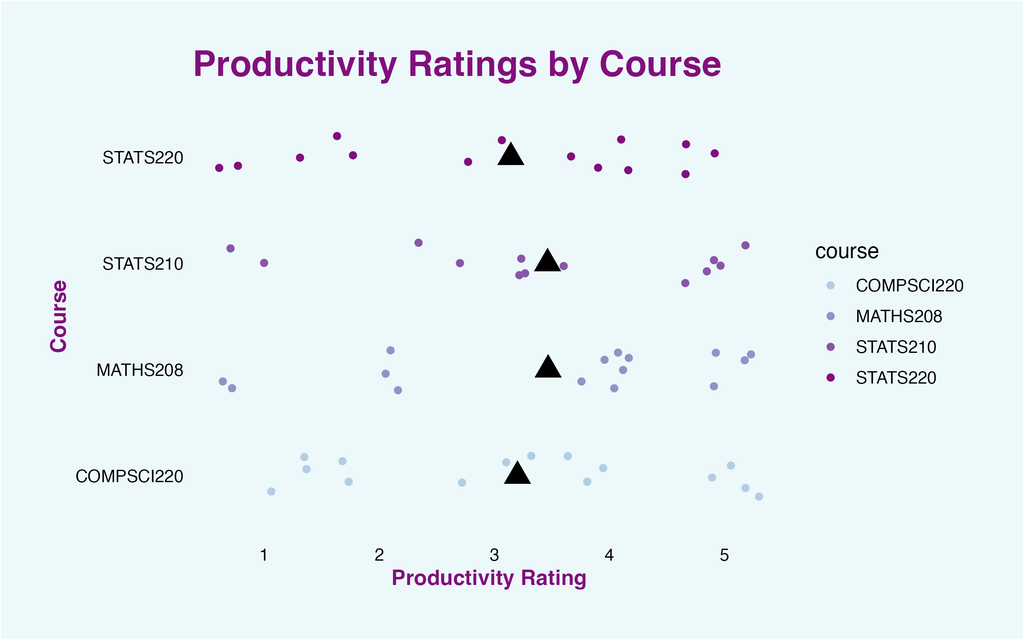

Jitter plot comparing productivity ratings across university courses.

## How long do study sessions last?

My second plot explores the distribution of study session duration. The density curve shows where study session lengths are most concentrated, and the vertical line shows the average duration. We can see the density curve peaks at approximately 60 minutes. This is to be expected, as that is a common amount of time to focus for (e.g., lectures, tutorials, or an hour of focused test study). There is another small peak at 120 minutes; this could be due to setting a timer for a 2-hour study session. After that, the graph drops off sharply, as it may be difficult to study for more than 2 hours; thus, there are many fewer observations in that range. The average duration appears to be about 75 minutes. This graph helps provide insight into typical study behavior patterns.

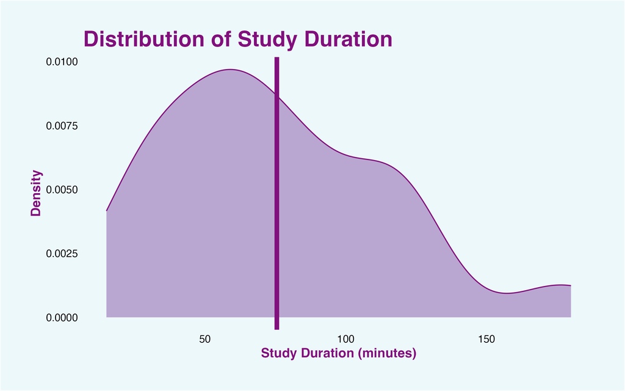

Density plot showing the distribution of study session duration in minutes

## Does productivity change throughout the day?

This plot uses timestamp data to investigate how productivity changes throughout the day. This graph suggests productivity is very high earlier in the morning, averaging at 4.5 at 10 am and 4 at 11 am. This makes sense, as in the morning your brain is fresh, has had a good amount of sleep, and hasn’t yet had much to think about. The plot drops a bit at 12 pm and then even more at 3 pm, to about 2.5. I would say this is also explainable, you are starting to get tired, might be wanting a nap, might be distracted by eating lunch, etc. The graph then jumps back up to around 3.5 at 6 pm. This plot clearly shows the student works best in the mornings, has a bit of a slump in the afternoon, and then perks back up in the evening. This can be very helpful when planning study sessions. You could ensure to do the more difficult content in the morning, the easier stuff in the afternoon, and some more tricky stuff in the evening. The visualisation shows that productivity levels may fluctuate depending on the time of day.

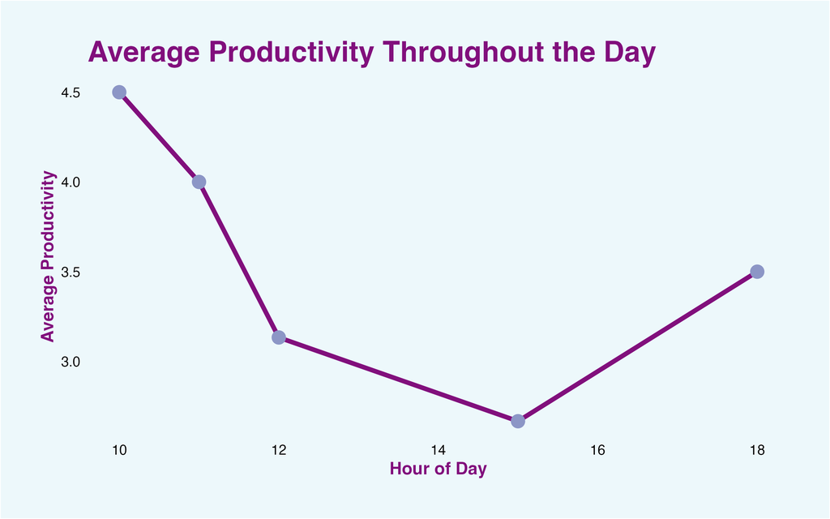

Line graph showing average productivity at different hours of the day

## Which courses were studied the most often?

My fourth plot shows the number of study sessions logged for each course. This visulaisation helps communicate differences in study frequency across different courses. We can see that Stats210 had the least amount of study sessions, and Maths208 and CompSci220 tied for the most. It’s important to note that this graph doesn’t show the total amount of time spent on each course, but rather the number of study sessions. So stats210 could have been worked on a lot, but happened to have longer and less frequent sessions, and vice versa for the other courses.

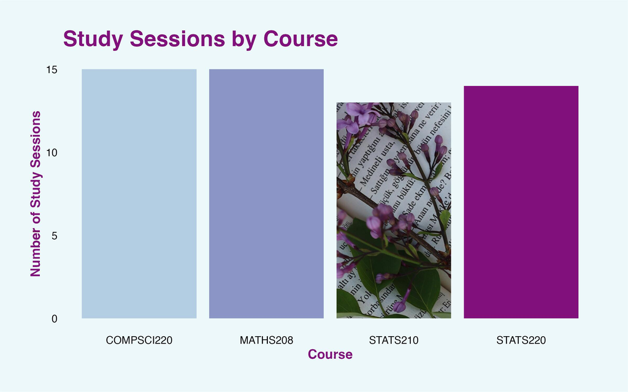

Bar graph showing the number of study sessions recorded depending on course